# VAR/VECM Project

Caitlin Brown

April 23, 2022

```r
require(fpp3)
require(tidyverse)
require(dplyr)
require(tidyquant)
require(lubridate)
require(timetk)
require(vars)
require(lmtest)
require(kableExtra)
require(stargazer)
require(urca)
require(tsDyn)
require(apt)
require(tsibble)
```

# Investigating the Dynamic relationship of Female Employment and Child Day Care Services

| Variable | Description |  |
| --- | --- | --- |
| CES6562440001 | All Employees, Child Day Care Services Seasonally Adjusted. The series comes from the Current Employment Statistics (Establishment Survey). Units in Thousands of Persons, Seasonally Adjusted and Frequ… |  |
| CES0000000010 | Seasonally Adjusted Women Employees, Total Non farm. Units in Thousands of Persons, Seasonally Adjusted and Frequency Monthly. The non farm business sector excludes the economic activities of the foll… |  |

### GitHub Link

https://github.com/Cjb23v/Project-One

For this study estimates a VAR model of the two variables. A VAR is a dynamic reduced form model that generalized the single auto regression by allowing for multivariate time series, it captures the relationship of changing quantities over time and is essentially a generalization of of uni-variate AR(p) model. VECM models are special cases of VAR models where all variables are stationary, generally outperforming VAR models.It allows for long term and short term inspection as well as co integration between variables. Co-integration also can reduce the possibility that variables have a relationship that look correlated but aren’t. For this reason the VECM model will also be freely explored.

Considering the relationship between total women employment in the US (CES0000000010) and total child daycare employment (CES6562440001). It is expected logical order follows, as more women are employed full time the necessities of child day care services also increases. If this is the case then female employment should *lead* child daycare services. There is possibility of the reverse being true, where abundance, or lack of, access to reliable (and affordable) Child day care services encourages, or deters, mothers to seek job opportunities.  
We begin by loading and plotting the raw data, as shown below:

```r
varList <- c("CES6562440001", "CES0000000010")
X <- tq_get(varList, get = "economic.data", from = "1985-01-01") %>%
  mutate(Date = yearmonth(date)) %>% dplyr::select(-date) %>%
  as_tsibble(index = Date, key = symbol)
Xw <- X %>%
  pivot_wider(names_from = symbol, values_from = price) %>%
  as_tsibble()
```

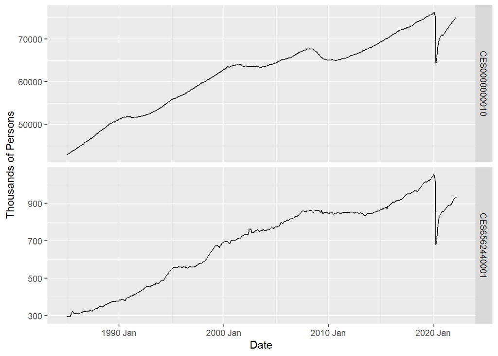

```r
X %>% ggplot(aes(x = Date, y = price)) +
  geom_line() + ylab("Thousands of Persons") +
  facet_grid(vars(symbol), scales = "free_y")
```

```r
X %>%
  features(price, unitroot_ndiffs) %>%
  kable(format = "html", table.attr = "style='width:30%;' ") %>%
  kableExtra::kable_styling()
```

| symbol | ndiffs |
| --- | --- |
| CES0000000010 | 1 |
| CES6562440001 | 1 |

```r
ZEmploy <- Xw %>%
  mutate(gFemEmpl = 100 * difference(log(CES0000000010)),
         gChildCare = 100 * difference(log(CES6562440001))) %>%
  dplyr::select(gFemEmpl, gChildCare) %>%
  tidyr::drop_na()
zEmploy <- as.ts(ZEmploy, start = c(1985, 2), frequency = 12)
```

After modeling the monthly growth rates of Women who are employed and child day care services. Next is to find how many lags are needed in our VAR model. This is done below, to find optimal lag length selection we’ll use the Hannan-Quin criterion since it works well for fairly large sample sizes (we find the optimal length is 4 according to this criterion). For choosing a p, it is safer to overestimate than to underestimate p, a p too small will omit important lag variables and render estimators inconsistent. In VAR models the *order* of the variable is going to matter when we compute impulse response functions, so the order of the variables from first to last is the most exogenous to most endogenous. We’d usually guess at this but in my opinion the logical action is female employment precedes child day care services, as reason dictates mothers would only be in need of child care after employment.

```r
zE <- zEmploy[,c(1,2)]
tmp <- VARselect(zE,lag.max=12,type="const")
tmp
p <- tmp$selection[2]
```

[output not shown]

The Granger Tests low F-statistics of both tests, which is less than the F-critical value found in table, leads me too believe non-significance. As well as the high probability values of the F-statistic supports the notion neither of my results are significant.What we test for is to know whether lagged values of gFemEmploy help to forecast future values of gChildCare. If so we say that gFemEmloy *causes* gChildCare) and if not we say the opposite, from this I would conclude that neither predicts the other.

```r
cat("H0: Access to Child Day Care doesn't cause Female Employment, H1: it does \n")
```

```
## H0: Access to Child Day Care doesn't cause Female Employment, H1: it does
```

```r
grangertest(gFemEmpl ~ gChildCare, order=p, data = zE)
```

|  | Res.Df | Df | F | Pr(>F) |
| --- | --- | --- | --- | --- |
| 1 | 433 | NA | NA | NA |
| 2 | 437 | -4 | 1.318795 | 0.2620824 |

```r
cat("H0:  Female Employment doesn't cause Child Day Car Service, H1: it does \n")
```

```
## H0:  Female Employment doesn't cause Child Day Car Service, H1: it does
```

```r
grangertest(gChildCare ~ gFemEmpl, order=p, data = zE)
```

|  | Res.Df | Df | F | Pr(>F) |
| --- | --- | --- | --- | --- |
| 1 | 433 | NA | NA | NA |
| 2 | 437 | -4 | 0.6863247 | 0.6017215 |

```r
#verifying that our estimated residuals are indeed white noise to make sure that we have not chosen too small a value for `p`
fit <-VAR(zEmploy)
tidy(fit)
```

[output not shown]

Below is the Estimated Vector Auto-regression model by utilizing OLS per equation. Estimates a VAR by OLS per equation. The model is of the following form:

($y_{t} = A_{1yt−1} + . . . + A_{p}y_{t−p} + CD_{t} + u_{t}$) where ($y_{t}$) is a ($K × 1$) vector of endogenous variables and ($u_{t} $) assigns a spherical disturbance term of the same dimension. The estimated coefficients are not as telling as the significance of the *groups* of parameters with the implied dynamics from the estimation. The more significant interpretation can be gained from inspecting the Impulse Response Functions and the Forecasting Error Variance Decomposition.

```r
# estimate the VAR(p)
var.Employ<- VAR(zE,p=p,type="const")
summary(var.Employ)
```

```
##
## VAR Estimation Results:
## =========================
## Endogenous variables: gFemEmpl, gChildCare
## Deterministic variables: const
## Sample size: 442
## Log Likelihood: -984.218
## Roots of the characteristic polynomial:
## 0.6342 0.6108 0.5936 0.5936 0.5352 0.5352 0.4725 0.4725
## Call:
## VAR(y = zE, p = p, type = "const")
##
##
## Estimation results for equation gFemEmpl:
## =========================================
## gFemEmpl = gFemEmpl.l1 + gChildCare.l1 + gFemEmpl.l2 + gChildCare.l2 + gFemEmpl.l3 + gChildCare.l3 + gFemEmpl.l4 + gChildCare.l4 + const
##
##               Estimate Std. Error t value Pr(>|t|)
## gFemEmpl.l1    0.09303    0.14379   0.647   0.5180
## gChildCare.l1 -0.02548    0.05470  -0.466   0.6416
## gFemEmpl.l2   -0.11064    0.14402  -0.768   0.4428
## gChildCare.l2 -0.03525    0.05479  -0.643   0.5204
## gFemEmpl.l3    0.14095    0.14385   0.980   0.3277
## gChildCare.l3 -0.06537    0.05470  -1.195   0.2327
## gFemEmpl.l4    0.11044    0.14077   0.785   0.4331
## gChildCare.l4 -0.07604    0.05365  -1.417   0.1571
## const          0.14656    0.04021   3.645   0.0003 ***
## ---
## Signif. codes:  0 '***' 0.001 '**' 0.01 '*' 0.05 '.' 0.1 ' ' 1
##
##
## Residual standard error: 0.799 on 433 degrees of freedom
## Multiple R-Squared: 0.05253, Adjusted R-squared: 0.03503
## F-statistic: 3.001 on 8 and 433 DF,  p-value: 0.00275
##
##
## Estimation results for equation gChildCare:
## ===========================================
## gChildCare = gFemEmpl.l1 + gChildCare.l1 + gFemEmpl.l2 + gChildCare.l2 + gFemEmpl.l3 + gChildCare.l3 + gFemEmpl.l4 + gChildCare.l4 + const
##
```

[output cut: 14 more lines]

```
## Residual standard error: 2.107 on 433 degrees of freedom
## Multiple R-Squared: 0.0562,  Adjusted R-squared: 0.03876
## F-statistic: 3.223 on 8 and 433 DF,  p-value: 0.001428
##
##
##
## Covariance matrix of residuals:
##            gFemEmpl gChildCare
## gFemEmpl     0.6384       1.59
## gChildCare   1.5897       4.44
##
## Correlation matrix of residuals:
##            gFemEmpl gChildCare
## gFemEmpl     1.0000     0.9443
## gChildCare   0.9443     1.0000
```

The Impulse Response Functions (IRFs), they are usually presented as a set of 4 with the red dotted lines of the IRF indicating the 95% confidence intervals. Looking at the IRFs will tell us about the dynamics, it will measure changes in future responses of all variables in the time series when a variable is shocked by an impulse to another variable. This is more significant to look at than the VAR estimate coefficient, and from this we can see, even though we have may not have a statistically significant feedback system, female employment has a slightly little more influence on Child day care services than the other way around.

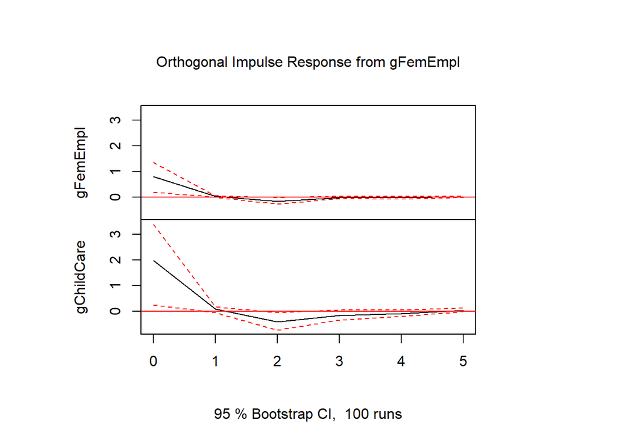

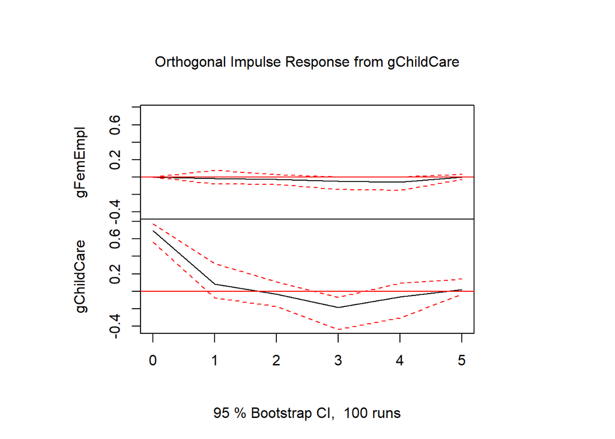

```r
plot(irf(var.Employ, n.ahead = 5, boot = TRUE ))
```

The Forecasting Error Variance Decomposition, FEVD, “decomposes” the variance of the forecast error into the contributions from specific exogenous shocks and confirms what we see from the IRFs. Much of the forecast variance in female employment is due to female employment variation itself, the variance of child day care serves has very little influence. However, about 90% of the forecast variance of child day care can be explained by the variance in female employment. As the results show below, it is a intuitive way of determining the movements of female employment drive movements in child day care services but not *vice versa*.

```r
fevd(var.Employ, n.ahead = 12)
```

```
## $gFemEmpl
##        gFemEmpl   gChildCare
##  [1,] 1.0000000 0.0000000000
##  [2,] 0.9995117 0.0004883171
##  [3,] 0.9983400 0.0016599556
##  [4,] 0.9948925 0.0051075231
##  [5,] 0.9902417 0.0097583375
##  [6,] 0.9902373 0.0097626982
##  [7,] 0.9900274 0.0099725619
##  [8,] 0.9900025 0.0099974512
##  [9,] 0.9899534 0.0100466149
## [10,] 0.9899236 0.0100763889
## [11,] 0.9899199 0.0100800539
## [12,] 0.9899192 0.0100807795
##
## $gChildCare
##        gFemEmpl gChildCare
##  [1,] 0.8917032  0.1082968
##  [2,] 0.8906394  0.1093606
##  [3,] 0.8944100  0.1055900
##  [4,] 0.8885912  0.1114088
##  [5,] 0.8879132  0.1120868
##  [6,] 0.8878632  0.1121368
##  [7,] 0.8874406  0.1125594
##  [8,] 0.8874419  0.1125581
##  [9,] 0.8874321  0.1125679
## [10,] 0.8874136  0.1125864
## [11,] 0.8874137  0.1125863
## [12,] 0.8874134  0.1125866
```

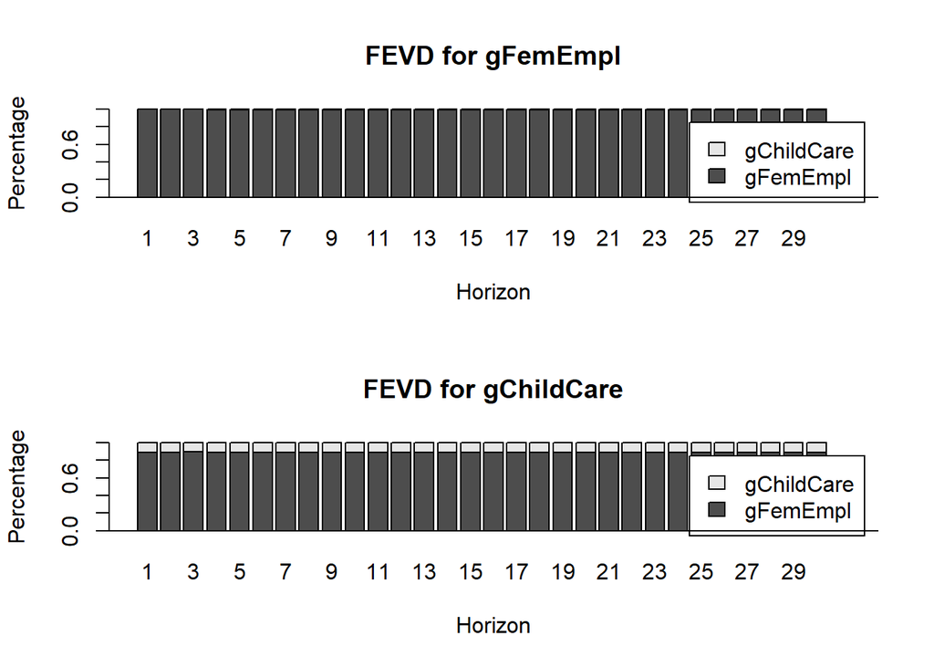

```r
plot(fevd(var.Employ, n.ahead = 30))
```

The code below also estimate the Vector Error Correction Model simply for comparison, the var depicts short-term dynamics only but the VECM has the benefits of both long-term and short-term.

```r
VECM(
  zE[,c(1,2)],
  lag=p,
  r = 1,
  include = c("const"),
  beta = NULL,
  estim = c("ML"),
  LRinclude = c("none"),
)
```

[output not shown]

### Conclusions

From the Results of FEVD, IRF, and the Var model it would there not much significance of a leading relationship being present between the two variables, if there is it is minimal in scope, with more likely other factors acting as a more impactful *leading* variables. Although impacts of female employment are not statistically significant according to the p-values of our estimates VAR model, our IRF and FEVD indicate that female employment levels are useful in predicting the levels of Child Day care Services. Variables that would likely be more statistically significant in predicting levels of child day care services would be levels of married couples as well as working women, or Simply levels of Employed women with dependents. We also find that shocks to Child day care services have little to no impact on female employment levels, which is a reasonable conclusion since majority of women will have a back-up plan in place, such as family members, should they not have the means to afford day care.